# Supplementary Information:Brief Guide to Code

### Figures for Unbalanced Consumer-Resource Interactions

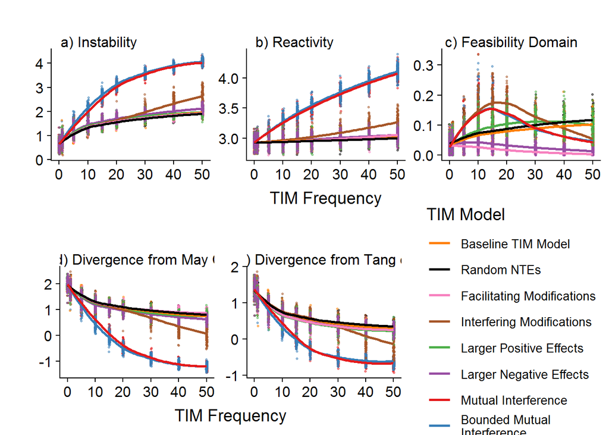

```r
dataU05%>%
  filter(TIM_Model %in% Interesting) %>%
  mutate(Instability = log(obs),
         Reactivity=log(Reactivity)) %>%
  gather('Response', 'Value',
         Instability,
         Omega,
         Reactivity)%>%
  mutate(Response = factor(Response,
                           levels= c('Instability',
                                     'Reactivity',
                                     'Omega'),
                           labels = Labels <- c('a) Instability',
                                                'b) Reactivity',
                                                'c) Feasibility Domain')))%>%
  ggplot(aes(y=Value, x=TIM_Dens, col=TIM_Model))+
  geom_jitter(size=0.5 , width = 0.2, height = 0, alpha = 0.5 )+
  geom_smooth(se = FALSE)+
  facet_wrap(~Response, scales = 'free' )+
  guides(col=FALSE)+
  theme(strip.background = element_blank(),
        strip.text = element_text(hjust = 0.1, margin = margin(1,1,1,1)))+
  labs(title="",
       y='',
       x='TIM Frequency')+InterestingColours -> TopRow


dataU05 %>%
  filter(TIM_Model %in% Interesting) %>%
  mutate(Stability = log(obs),
         `Divergence from Tang Criterion` = log(Tang)-Stability,
         `Divergence from May Criterion` = log(May)-Stability) %>%
  gather('Response', 'Value',
         `Divergence from Tang Criterion`,
         `Divergence from May Criterion`)%>%
  mutate(Response = factor(Response,
                           levels= c('Divergence from May Criterion',
                                     'Divergence from Tang Criterion' ),
                           labels = c('d) Divergence from May Criterion',
                                      'e) Divergence from Tang et al. Criterion' )))%>%
  ggplot(aes(y=Value, x=TIM_Dens, col=TIM_Model))+
  geom_jitter(size=0.5 , width = 0.2, height = 0, alpha = 0.5 )+
  geom_smooth( se = FALSE)+
  facet_wrap(~Response, scales = 'free')+
  theme(strip.background = element_rect(fill = 'white'),
        strip.text = element_text(hjust = 0.1, margin = margin(1,1,1,1)))+
  labs(title="",
       y='',
       x='TIM Frequency')+InterestingColours+
  LEGEND-> BottomRow

BothdataUn<-cowplot::plot_grid(TopRow, BottomRow, nrow = 2)
BothdataUn
```

```r
ggsave('Paper/Figures/SuppInfo/Unbalanced.pdf', width = 12, height = 9)
ggsave('Paper/Figures/SuppInfo/Unbalanced.png', width = 12, height = 9, dpi=300)
```

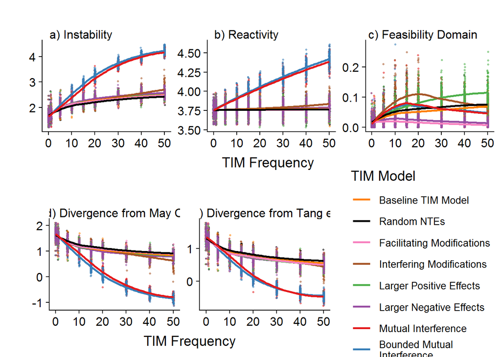

```r
dataV05%>%
  filter(TIM_Model %in% Interesting) %>%
  mutate(Instability = log(obs),
         Reactivity=log(Reactivity)) %>%
  gather('Response', 'Value',
         Instability,
         Omega,
         Reactivity)%>%
  mutate(Response = factor(Response,
                           levels= c('Instability',
                                     'Reactivity',
                                     'Omega'),
                           labels = Labels <- c('a) Instability',
                                                'b) Reactivity',
                                                'c) Feasibility Domain')))%>%
  ggplot(aes(y=Value, x=TIM_Dens, col=TIM_Model))+
  geom_jitter(size=0.5 , width = 0.2, height = 0, alpha = 0.5 )+
  geom_smooth(se = FALSE)+
  facet_wrap(~Response, scales = 'free' )+
  guides(col=FALSE)+
  theme(strip.background = element_blank(),
        strip.text = element_text(hjust = 0.1, margin = margin(1,1,1,1)))+
  labs(title="",
       y='',
       x='TIM Frequency')+InterestingColours -> TopRow

dataV05%>%
  filter(TIM_Model %in% Interesting) %>%
  mutate(Stability = log(obs),
         `Divergence from Tang Criterion` = log(Tang)-Stability,
         `Divergence from May Criterion` = log(May)-Stability) %>%
  gather('Response', 'Value',
         `Divergence from Tang Criterion`,
         `Divergence from May Criterion`)%>%
  mutate(Response = factor(Response,
                           levels= c('Divergence from May Criterion',
                                     'Divergence from Tang Criterion' ),
                           labels = c('d) Divergence from May Criterion',
                                      'e) Divergence from Tang et al. Criterion' )))%>%
  ggplot(aes(y=Value, x=TIM_Dens, col=TIM_Model))+
  geom_jitter(size=0.5 , width = 0.2, height = 0, alpha = 0.5 )+
  geom_smooth(se = FALSE)+
  facet_wrap(~Response, scales = 'free')+
  theme(strip.background = element_rect(fill = 'white'),
        strip.text = element_text(hjust = 0.1, margin = margin(1,1,1,1)))+
  labs(title="",
       y='',
       x='TIM Frequency')+InterestingColours+
  LEGEND-> BottomRow

BothdataVeryUn<-cowplot::plot_grid(TopRow, BottomRow, nrow = 2)
BothdataVeryUn
```

```r
ggsave('Paper/Figures/SuppInfo/VeryUnbalanced.pdf', width = 12, height = 9)
ggsave('Paper/Figures/SuppInfo/VeryUnbalanced.png', width = 12, height = 9, dpi=300)
```

# Correlation of Feasibility With Network Features

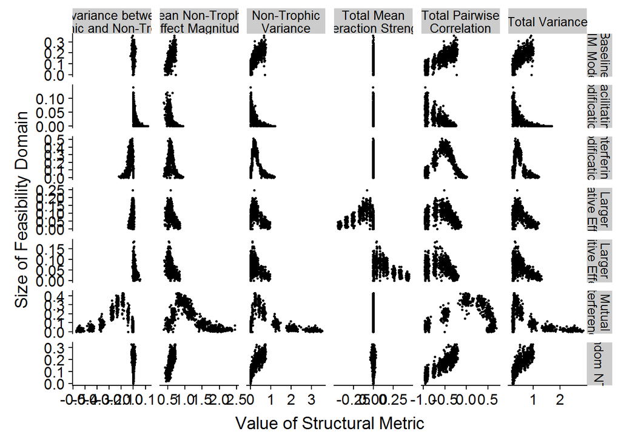

```r
data2 %>%
  filter(TIM_Model %in% c("Normal","Random","Positive",
                          "Negative","IncSkew","DecSkew", "Switching")) %>%
mutate(TIM_Model = ifelse(TIM_Model=="Normal" ,  "Baseline\nTIM Model"  ,TIM_Model),
       TIM_Model = ifelse(TIM_Model=="Random" , "Random NTEs" ,TIM_Model),
       TIM_Model = ifelse(TIM_Model== "Positive",  "Facilitating\nModifications" ,TIM_Model),
       TIM_Model = ifelse( TIM_Model=="Negative", "Interfering\nModifications",TIM_Model),
       TIM_Model = ifelse(TIM_Model=="IncSkew", "Larger\nPositive Effects" ,TIM_Model),
       TIM_Model = ifelse(TIM_Model=="DecSkew" , "Larger\nNegative Effects",TIM_Model),
       TIM_Model = ifelse(TIM_Model== "Switching",  "Mutual\nInterference",TIM_Model))%>%
    select(Omega,TIM_Model,
         V, C_VAR, cov, rho,mu, MeanMagNT)%>%
  rename(`Total Variance`=V,
         `Non-Trophic\nVariance`= C_VAR,
         `Covariance between\nTrophic and Non-Trophic`=cov,
         `Total Pairwise\nCorrelation`=rho,
         `Total Mean\nInteraction Strength`=mu,
         `Mean Non-Trophic\nEffect Magnitude`=MeanMagNT)%>%
  gather( 'Metric', 'Value', `Total Variance`:`Mean Non-Trophic\nEffect Magnitude`)%>%
  ggplot(aes(Value, Omega))+
  geom_point(size =0.5)+
    facet_grid(TIM_Model~Metric, scales = 'free')+
  ylab('Size of Feasibility Domain')+
  xlab('Value of Structural Metric')+
  guides(col=FALSE)+
  theme(strip.text = element_text(size = 10))
```

```r
ggsave('Paper/Figures/SuppInfo/EffectOfStructureOnFeasib.pdf', width=11, height = 11)
ggsave('Paper/Figures/SuppInfo/EffectOfStructureOnFeasib.png', width=11, height = 11, dpi=300)
```

# Supplementary Rho Figures

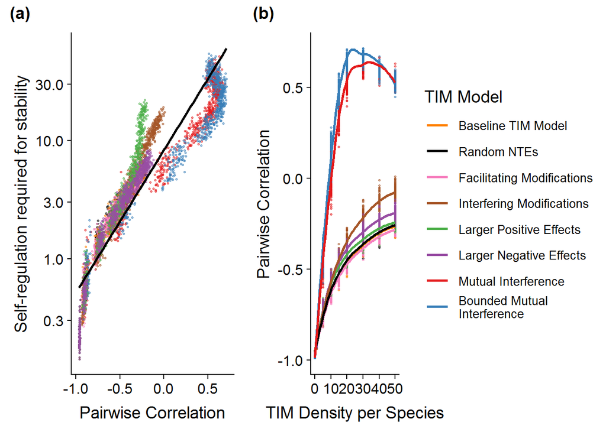

```r
data2 %>%
  filter(TIM_Model %in% Interesting) %>%
  ggplot(aes(y=obs, x=rho))+
  scale_y_log10()+
  geom_point(size=0.5, alpha=0.5, aes(col=TIM_Model))+
  geom_smooth(se = FALSE, method = lm , col='black')+
  labs(title="",
       y='Self-regulation required for stability',
       x='Pairwise Correlation')+ InterestingColours+LEGEND -> RhoStab

data2 %>%
  filter(TIM_Model %in% Interesting) %>%
  ggplot(aes(y=rho, x=TIM_Dens, col=TIM_Model))+
  geom_point(size=0.5, alpha=0.5)+
  geom_smooth(se = FALSE)+
  labs(title="",
       y='Pairwise Correlation',
       x='TIM Density per Species')+ InterestingColours+LEGEND -> TIMRho

BothRhoPlots<-plot_grid(RhoStab+guides(col=FALSE), TIMRho, rel_widths = c(2,3), labels = c('(a)', '(b)'))
BothRhoPlots
```

```r
ggsave('Paper/Figures/SuppInfo/SIBothRhoPlots.png', BothRhoPlots, width = 12, height = 6, dpi = 300)
ggsave('Paper/Figures/SuppInfo/SIBothRhoPlots.pdf', BothRhoPlots, width = 12, height = 6)
```

# Other Small analyses

### Figure Explaining row structure paterning

The trophic interaction matrices do not have the characteristic banding pattern than is commonly observed in empirical networks.

Here we multiply each trophic interaction matrix and each non-trophic interaction matrix by a vector of positive numbers that represent the biomass terms of each of the species.

These vectors are drawn from a log-normal distribution ( so the values are always positive, and therefore has a distribution appropriate), to give a distribution of mean 1 and SD of approximately 2.5

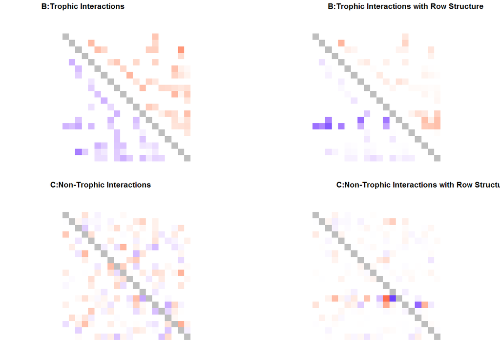

```r
set.seed(1)

B <- BuildWeb(mux = -1 , muy = 1,
              sigmax = 0.5, sigmay = 0.5, size=20,
              rhoxy = -0.8, connectance =0.3)
A <-  AddTIMsToMatrix(B,'Random',TIM_Dens = 5, TIMStrength = 0.5)

C <- A-B
V <- rlnorm(dim(B)[1], -1, sqrt(2))
B_row = B*V
C_row = C*V

OrigB <- PlotMatrix(B, '')
OrigC <- PlotMatrix(C, '')
RowSB <- PlotMatrix(B_row, '')
RowSC <- PlotMatrix(C_row, '')

Combined <- plot_grid(OrigB,RowSB, OrigC,RowSC,  ncol=2, labels = c('B:Trophic Interactions',
                                                                    'B:Trophic Interactions with Row Structure',
                                                                    'C:Non-Trophic Interactions',
                                                                    'C:Non-Trophic Interactions with Row Structure'), label_x = 0, label_size = 8  )
Combined
```

## Balance of positive element

```r
data2 %>%
  filter(DotToRightOfDiskMay == TRUE) %>%
  group_by(TIM_Dens)%>%
  summarise(n())
```

```
## # A tibble: 6 x 2
##   TIM_Dens `n()`
##      <dbl> <int>
## 1       10    62
## 2       15   100
## 3       20   100
## 4       30   100
## 5       40   100
## 6       50   100
```

```r
data2 %>%
  filter(DotToRightOfDiskTang == TRUE) %>%
  group_by(TIM_Model)%>%
  summarise(n())
```

```
## # A tibble: 16 x 2
##    TIM_Model  `n()`
##    <chr>      <int>
##  1 BoundSw        8
##  2 DecSkew        8
##  3 EcoEng         8
##  4 Far            8
##  5 IncSkew      795
##  6 LaPlace        8
##  7 Nearby         8
##  8 Negative       8
##  9 Normal         8
## 10 Positive       8
## 11 Random         9
## 12 RanSkew        8
## 13 Scaled         8
## 14 Switching      8
## 15 TightRecip     8
## 16 Unif           8
```

## Hermetian Matrices from communities with NTEs

What is driving the reactivity patterns?

```r
# adding random NTEs back in for competeness
ModelList <- c('Random', ModelList)
```

```r
B <- BuildWeb(mux = -1 , muy = 1,
              sigmax = 0.5, sigmay = 0.5, size=30,
              rhoxy = -0.8, connectance =0.2)
```

```r
H_Matrices<- map(ModelList, PlotH, B, 20, 0.5 )
```

```
## [1] "Random"
## [1] "Normal"
## [1] "Nearby"
## [1] "Far"
## [1] "EcoEng"
## [1] "TightRecip"
## [1] "Positive"
## [1] "Negative"
## [1] "Unif"
## [1] "LaPlace"
## [1] "Scaled"
## [1] "RanSkew"
## [1] "IncSkew"
## [1] "DecSkew"
## [1] "Switching"
## [1] "BoundSw"
```

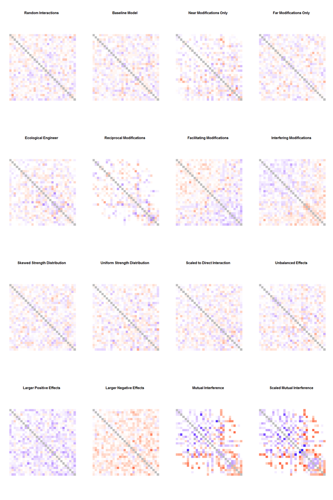

```r
plot_grid(plotlist = c(H_Matrices ), ncol = 4 )+
  draw_plot_label(label=c('Random Interactions',matLABELS),
                  x=rep((0.5+(0:3))/4, 4),
                  y=1-(1-0.9+rep(0:3, each=4))/4,
                  hjust=.5, vjust=.5, size=6)
```

```r
ggsave('Paper/Figures/SuppInfo/HermitianMatrices.pdf', width = 6, height =8)
```